# CH1 : Visualisation des donnees tabulaires

TP1

```r
library(dplyr)
library(ggplot2)
```

# Énoncé

Pour ce TP nous allons utiliser un jeu de donnees contient des mesures morphologiques pour trois especes de pingouins observees sur trois iles de l’archipel Palmer, en Antarctique.

Ce jeu de donnees comprend 6 variables et 333 individus. Les trois especes de pingouins observees sont:

- Adelie
- Gentoo
- Chinstrap

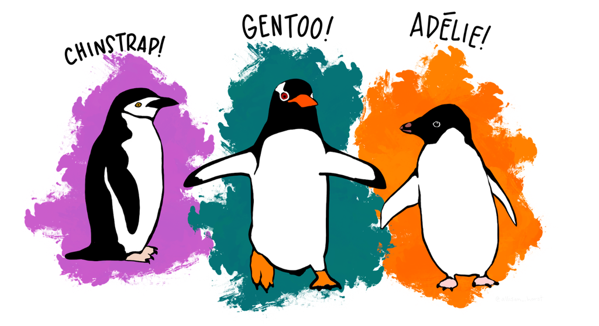

penguins

Telecharger les donnees penguins et explorer-les a l’aide de la visualisation

# Exploration des données

Je télécharge les données et je les importe

```r
penguins <- read.csv("data/data_penguins.csv", sep = ",")
```

```r
head(penguins)
```

```
##   species bill_length_mm bill_depth_mm flipper_length_mm body_mass_g    sex
## 1  Adelie           35.1          19.4               193        4200   male
## 2  Adelie           36.3          19.5               190        3800   male
## 3  Adelie           36.0          17.9               190        3450 female
## 4  Adelie           36.0          17.8               195        3450 female
## 5  Adelie           38.8          20.0               190        3950   male
## 6  Adelie           39.6          20.7               191        3900 female
```

J’affiche les informations sur le jeu de données

```r
summary(penguins)
```

```
##    species          bill_length_mm  bill_depth_mm   flipper_length_mm
##  Length:333         Min.   :32.10   Min.   :13.10   Min.   :172
##  Class :character   1st Qu.:39.50   1st Qu.:15.60   1st Qu.:190
##  Mode  :character   Median :44.50   Median :17.30   Median :197
##                     Mean   :43.99   Mean   :17.16   Mean   :201
##                     3rd Qu.:48.60   3rd Qu.:18.70   3rd Qu.:213
##                     Max.   :59.60   Max.   :21.50   Max.   :231
##   body_mass_g       sex
##  Min.   :2700   Length:333
##  1st Qu.:3550   Class :character
##  Median :4050   Mode  :character
##  Mean   :4207
##  3rd Qu.:4775
##  Max.   :6300
```

J’affiche le nombre de lignes et de colonnes du jeu de données

```r
dim(penguins)
```

```
## [1] 333   6
```

# Visualisation des données

## Espèce

Voici un affichage du nombre d’individus pour chaque espèce de pingouin, dans un diagramme en camembert.

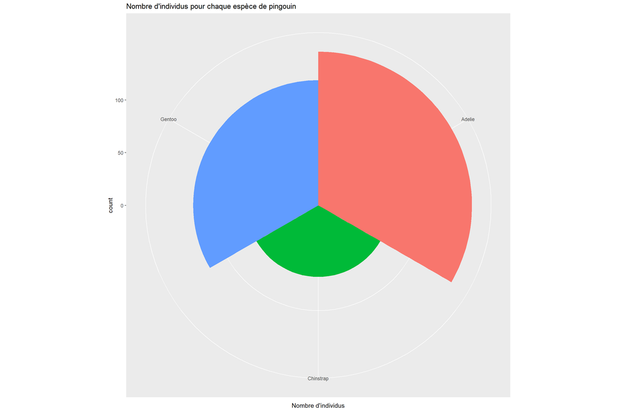

```r
graphbyspecies <- ggplot(data = penguins, aes(y = species, fill = species)) + geom_bar(width = 1) + coord_polar("y", start = 0) + labs(title = "Nombre d'individus pour chaque espèce de pingouin", y = "Nombre d'individus") + theme(legend.position = "none")
graphbyspecies
```

## Sexe/espèce

Voici un affichage du nombre de mâles et de femelles pour chaque espèce de pingouin, dans un graphique en barre.

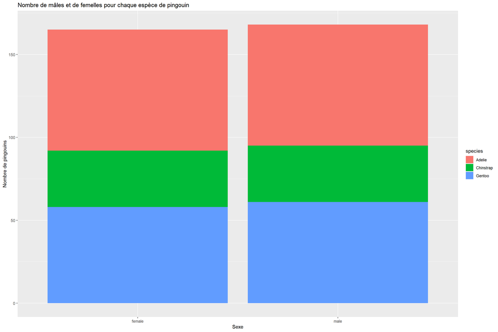

```r
graphbysex <- ggplot(data = penguins, aes(x = sex)) + geom_bar(aes(fill = species)) + labs(title = "Nombre de mâles et de femelles pour chaque espèce de pingouin", x = "Sexe", y = "Nombre de pingouins")
graphbysex
```

## Longueur du bec/masse corporelle/espèce

Voici un affichage de la longueur du bec en fonction de la masse corporelle pour chaque espèce de pingouin, dans un graphique en nuage de points, coloré selon l’espèce de l’individu concerné.

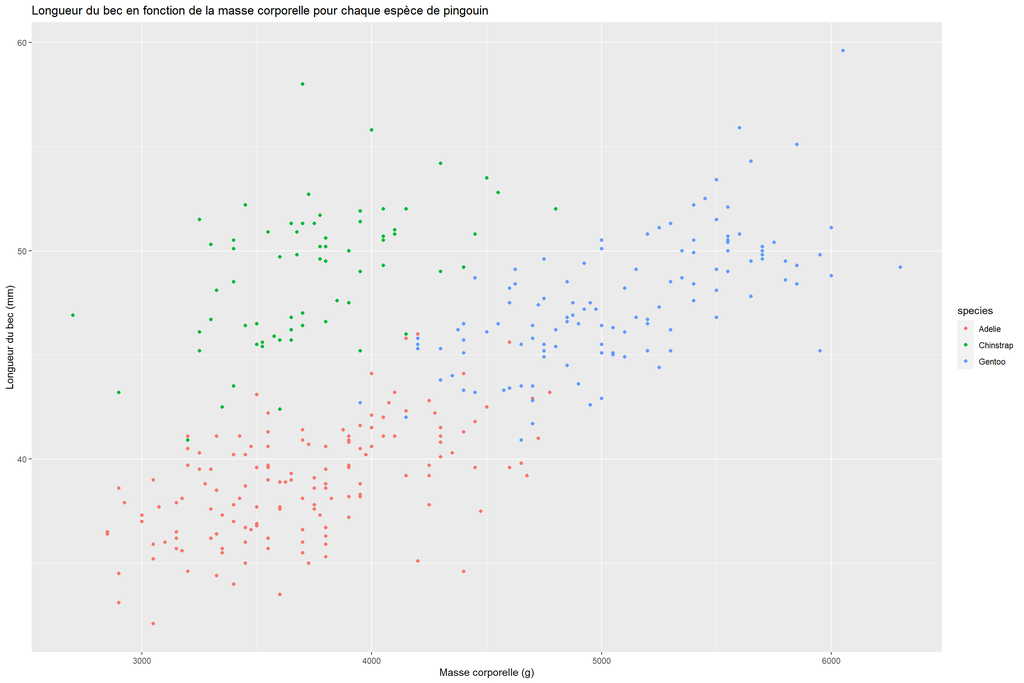

```r
graphbeakbybodymass <- ggplot(data = penguins, aes(x = body_mass_g, y = bill_length_mm, color = species)) + geom_point() + labs(title = "Longueur du bec en fonction de la masse corporelle pour chaque espèce de pingouin", x = "Masse corporelle (g)", y = "Longueur du bec (mm)")
graphbeakbybodymass
```

## Longueur des palmes/masse corporelle/espèce

Voici un affichage de la longueur des palmes en fonction de la masse corporelle pour chaque espèce de pingouin, dans un graphique en nuage de points, coloré selon l’espèce de l’individu concerné.

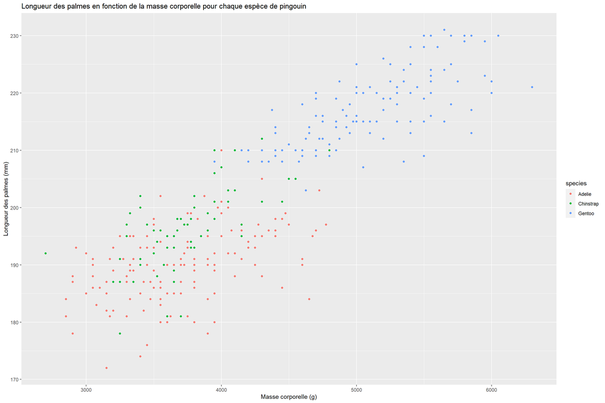

```r
graphflipbybodymass <- ggplot(data = penguins, aes(x = body_mass_g, y = flipper_length_mm, color = species)) + geom_point() + labs(title = "Longueur des palmes en fonction de la masse corporelle pour chaque espèce de pingouin", x = "Masse corporelle (g)", y = "Longueur des palmes (mm)")
graphflipbybodymass
```

# Conclusion

## Longueur du bec/longueur des palmes/masse corporelle/espèce

Voici un affichage de la longueur du bec en fonction de la longueur des palmes pour chaque espèce de pingouin, dans un graphique en nuage de points, coloré selon l’espèce de l’individu concerné et dont la taille des points dépends de la masse corporelle.

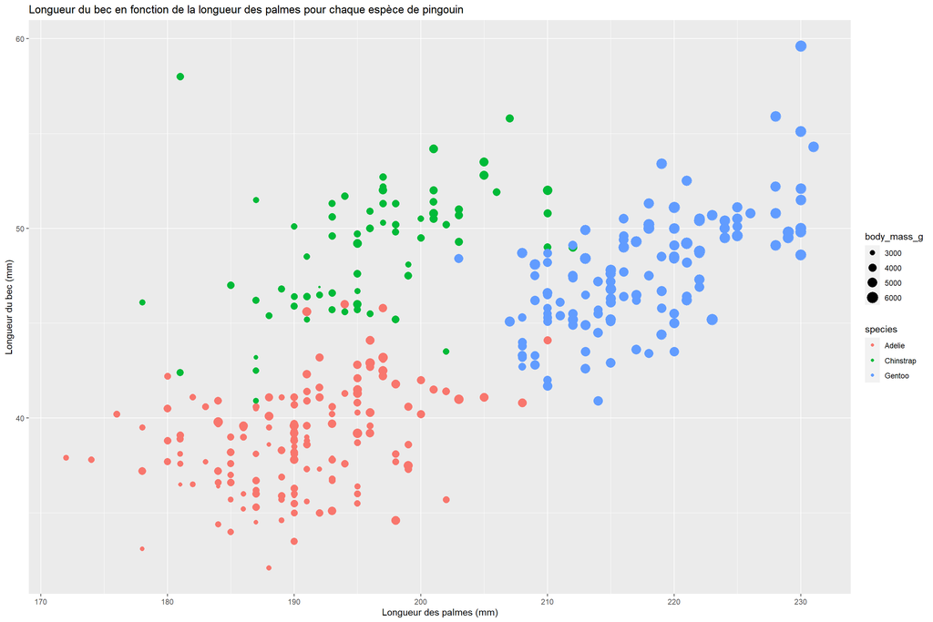

```r
graphbeakbyflipper <- ggplot(data = penguins, aes(x = flipper_length_mm, y = bill_length_mm, color = species, size = body_mass_g)) + geom_point() + labs(title = "Longueur du bec en fonction de la longueur des palmes pour chaque espèce de pingouin", x = "Longueur des palmes (mm)", y = "Longueur du bec (mm)")
graphbeakbyflipper
```

## Résumé des données

Les pingouins de l’espèce “Adelie” sont en général les plus léger, avec de petites palmes et un petit bec.

Les pingouins de l’espèce “Gentoo” sont en général les plus lourd, avec les plus grandes palmes et un grand bec aussi long que les “Chinstrap”.